# フィットネス事業 データ分析レポート

売上・利益向上に向けた分析と施策提案

## データセッティング

#### パッケージを読み込み

**コードを表示**

```r
# ── パッケージ読み込み ────────────────────────────────
# データ操作・可視化・モデリングに必要なパッケージ

library(readxl)       # Excelファイル読み込み
library(dplyr)        # データ操作（filter, mutate, select等）
library(tidyr)        # データ整形（pivot_longer, replace_na等）
library(ggplot2)      # グラフ作成
library(forcats)      # 因子型の操作（fct_reorder等）
library(scales)       # 軸ラベルのフォーマット（percent, comma等）
library(knitr)        # テーブル表示（kable）
library(kableExtra)   # テーブルのスタイリング
library(pROC)         # ROC曲線・AUCの計算
library(randomForest) # Random Forestモデル
library(caret)        # 機械学習のラッパー（交差検証等）
library(gridExtra)    # 複数グラフの配置
library(tibble)       # rownames_to_column等
library(showtext)     # 日本語フォントのサポート


# ── 日本語フォント設定 ────────────────────────────────
# Googleフォント「Noto Sans JP」を使用
font_add_google("Noto Sans JP", "noto")
showtext_auto()  # 全グラフに自動適用

# ── ggplot2 テーマ設定 ────────────────────────────────
# 全グラフに共通のスタイルを適用
theme_set(
  theme_minimal(
    base_size   = 13,
    base_family = "noto"   # 日本語フォント
  ) +
  theme(
    plot.title       = element_text(face = "bold", size = 14),
    plot.subtitle    = element_text(color = "grey40", size = 11),
    panel.grid.minor = element_blank(),
    legend.position  = "bottom"
  )
)
```

#### データ読み込み

**コードを表示**

```r
# データ読み込み
df <- "fitness_gym_data.xlsx"

# 各シートを個別のデータフレームとして読み込み
users    <- read_excel(df, sheet = "ユーザーデータ")

training <- read_excel(df, sheet = "トレーニングログ")
#   有酸素運動・カロリー制限・トレーナー利用・来館回数・滞在時間

body     <- read_excel(df, sheet = "体組成ログ")
#   体重・体脂肪率・筋肉量の30日間の増減

purchase <- read_excel(df, sheet = "購入ログ")
#   注文番号・ユーザーID・商品ID・購入金額

products <- read_excel(df, sheet = "商品マスタ")
#   商品名・カテゴリ・価格

area_mst <- read_excel(df, sheet = "居住エリアマスタ")
#   エリアID・エリア名・都道府県リスト

# ── カラーパレット設定 ────────────────────────────────
PALETTE <- c("#2196F3", "#FF5722")
# 継続 = 青（#2196F3）
# 離脱 = オレンジ（#FF5722）
# → 全グラフで統一して使用
```

#### カラム名を英語に統一

**コードを表示**

```r
# ── カラム名を英語に統一 ──────────────────────────────
# 日本語カラム名はRで扱いにくいため英語に変換

colnames(users) <- c(
  "user_id",        # ユーザーID（結合キー）
  "age",            # 年齢
  "gender",         # 性別（1=男性, 2=女性）
  "area_id",        # 居住エリアID（マスタと紐付け）
  "reg_date",       # 登録日（入会日）
  "continued",      # 継続フラグ（1=継続, 0=離脱）
  "total_purchase", # 累計購入金額（円）
  "purpose"         # 目的（1=筋力肥大, 2=ボディメイク, 3=健康志向）
)

colnames(training) <- c(
  "user_id",      # ユーザーID（結合キー）
  "aerobic",      # 有酸素運動量（kcal）
  "calorie_ctrl", # カロリー制限量
  "trainer",      # トレーナー利用フラグ（1=利用, 0=未利用）
  "gym_visits",   # ジム来館回数（回）
  "gym_hours"     # ジム合計滞在時間（分）
)

colnames(body) <- c(
  "user_id",       # ユーザーID（結合キー）
  "delta_weight",  # 体重変化量（kg）入会時からの増減
  "delta_bodyfat", # 体脂肪率変化（%）入会時からの増減
  "delta_muscle"   # 筋肉量変化（kg）入会時からの増減
)

colnames(purchase) <- c(
  "order_id",   # 注文番号（1注文1行）
  "user_id",    # ユーザーID（結合キー）
  "product_id", # 商品ID（商品マスタと紐付け）
  "amount"      # 購入金額（円）
)

colnames(products) <- c(
  "product_id",   # 商品ID（結合キー）
  "product_name", # 商品名
  "category",     # カテゴリ（ウェア/サプリメント/グッズ）
  "price",        # 価格（円）
  "release_date"  # 発売日
)

colnames(area_mst) <- c(
  "area_id",     # エリアID（結合キー）
  "area_name",   # エリア名（例：関東地方）
  "prefectures"  # 都道府県リスト
)
```

#### ラベル付与

**コードを表示**

```r
# ── ラベル付与 ────────────────────────────────────────
# 数値コードを人間が読める文字列に変換する
# 理由: グラフ・テーブルで「1」より「男性」の方がわかりやすいため

users <- users %>%
  mutate(
    # 性別ラベル
    # 元データ: 1=男性, 2=女性
    gender_lbl = factor(
      gender,
      levels = c(1, 2),
      labels = c("男性", "女性")
    ),

    # 目的ラベル
    # 元データ: 1=筋力肥大, 2=ボディメイク, 3=健康志向
    purpose_lbl = factor(
      purpose,
      levels = c(1, 2, 3),
      labels = c("筋力肥大", "ボディメイク", "健康志向")
    ),

    # 継続フラグラベル
    # 元データ: 0=離脱, 1=継続
    continued_lbl = factor(
      continued,
      levels = c(0, 1),
      labels = c("離脱", "継続")
    )
  ) %>%

  # 居住エリア名をマスタから結合
  # area_id をキーに area_name を追加
  left_join(
    area_mst %>% select(area_id, area_name),
    by = "area_id"
  ) %>%

  # 年齢グループを作成
  # 連続値の年齢を5つのグループに分類
  # 理由: 個別年齢より年齢層でみた方がパターンが把握しやすいため
  mutate(
    age_group = cut(
      age,
      breaks = c(0, 24, 29, 34, 39, Inf), # 区切り点
      labels = c(
        "～24歳",    # 24歳以下
        "25～29歳",  # 25〜29歳
        "30～34歳",  # 30〜34歳
        "35～39歳",  # 35〜39歳
        "40歳～"     # 40歳以上
      ),
      right = TRUE  # 区切り点を右側に含む
                    # 例: (24,29] → 25〜29歳
    )
  )
```

#### マスターテーブルの作成

**コードを表示**

```r
# ── 分析用マスターテーブルの作成 ──────────────────────
# 3つのテーブルを user_id をキーに結合し
# 全分析で使う1つの大きなテーブルを作成する

master <- users %>%
  left_join(training, by = "user_id") %>%
  left_join(body, by = "user_id") %>%
  mutate(
    purchased = as.integer(total_purchase > 0)
# 購入経験フラグ
    # 0 = 未購入
    # 1 = 購入あり
  )
```

# 課題概要

[output not shown]

# ① 継続・離脱分析

## 全体の継続率

**コードを表示**

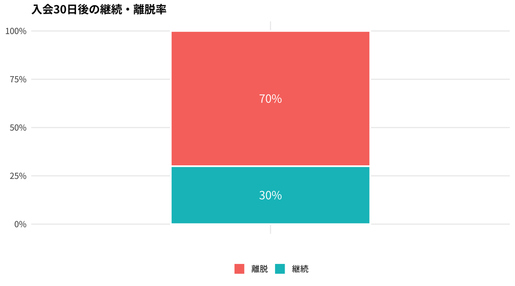

```r
# ── 全体の継続率の集計 ────────────────────────────────
# 継続・離脱それぞれの人数と割合を計算

cont_rate <- users %>%
  # 継続フラグ別に人数をカウント
  count(continued_lbl) %>%

  # 割合を計算
  # pct = 各グループの人数 / 全体の人数
  mutate(pct = n / sum(n))

# ── 横棒グラフで可視化 ───────────────────────────────
ggplot(cont_rate,
       aes(x = "",
           y = pct,
           fill = continued_lbl)) +

  # 棒グラフ
  geom_col(
    width     = 0.5,
    color     = "white",
    linewidth = 1.0
  ) +

  # 棒の中にテキストを表示
  geom_text(
    aes(label = percent(pct, 1)),
    position = position_stack(vjust = 0.5),
    color    = "white",    # 文字色を白に
    size     = 5
  ) +

  # y軸を%表示に変換
  scale_y_continuous(labels = percent) +

  labs(
    title = "入会30日後の継続・離脱率",
    x     = NULL,
    y     = NULL,
    fill  = NULL
  )
```

**コードを表示**

```r
# ── 継続・離脱の内訳テーブル ──────────────────────────
cont_rate %>%
  # pctを%文字列に変換（表示用）
  mutate(pct = percent(pct, 0.1)) %>%

  # 列名を日本語に変更（レポート用）
  rename(
    ステータス = continued_lbl,
    人数       = n,
    割合       = pct
  ) %>%
  kable(caption = "継続・離脱 内訳")
```

継続・離脱 内訳

| ステータス | 人数 | 割合 |
| --- | --- | --- |
| 離脱 | 140 | 70.0% |
| 継続 | 60 | 30.0% |

> **【全体の継続率】解釈**

> 入会から30日後の継続率は**30%（60人）**、 離脱率は**70%（140人）**であった。

> 約7割のユーザーが30日以内に離脱しており、 **離脱防止が最優先の経営課題**であることがわかる。

## 属性別の継続率

**コードを表示**

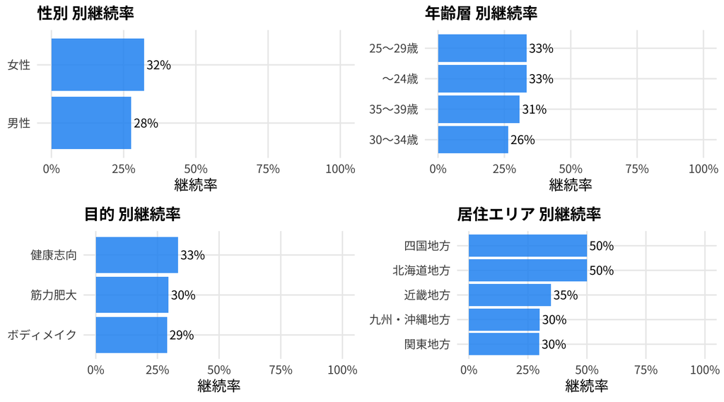

```r
# ── 属性別継続率を描画する関数 ────────────────────────
# 同じ処理を性別・年齢層・目的・エリアの4回行うため

# 引数:
# data  = 使用するデータフレーム（users）
# var   = グループ化する変数名（例: "gender_lbl"）
# label = グラフタイトルに使う日本語名（例: "性別"）

plot_cont_by <- function(data, var, label) {
  data %>%
    # 指定した変数と継続フラグでグループ化
    group_by(.data[[var]], continued_lbl) %>%

    # グループ別の人数をカウント
    summarise(n = n(), .groups = "drop") %>%

    # 各カテゴリ内での割合を計算
    group_by(.data[[var]]) %>%
    mutate(pct = n / sum(n)) %>%

    # 継続者の割合のみを抽出
    filter(continued_lbl == "継続") %>%

    # 継続率の高い順に並べて横棒グラフを作成
    ggplot(aes(
      x = fct_reorder(.data[[var]], pct), # 継続率順に並べる
      y = pct
    )) +
    geom_col(fill = PALETTE[1], alpha = 0.85) +

    # バーの右端に%ラベルを表示
    geom_text(
      aes(label = percent(pct, 1)),
      hjust = -0.1,  # ラベルを棒の右側に少しずらす
      size  = 3.8
    ) +
    coord_flip() +   # 横棒グラフに変換
    scale_y_continuous(
      labels = percent,
      limits = c(0, 1)  # 0%〜100%の範囲で表示
    ) +
    labs(
      title = paste(label, "別継続率"), # 例: "性別別継続率"
      x     = NULL,
      y     = "継続率"
    )
}

# ── 4つの属性別グラフを作成 ──────────────────────────
p1 <- plot_cont_by(users, "gender_lbl",  "性別")
p2 <- plot_cont_by(users, "age_group",   "年齢層")
p3 <- plot_cont_by(users, "purpose_lbl", "目的")
p4 <- plot_cont_by(users, "area_name",   "居住エリア")

# ── 2列×2行のグリッドで表示 ──────────────────────────
gridExtra::grid.arrange(p1, p2, p3, p4, ncol = 2)
```

> **【属性別継続率】解釈**

> **性別:** 女性（32%）が男性（28%）より わずかに継続率が高いが、 差は小さく性別による影響は限定的である。

> **年齢層:** 30〜34歳の継続率が26%と最も低く、 仕事・育児で多忙な世代の離脱が目立つ。 一方25〜29歳・〜24歳は33%と比較的高い。

> **目的:** 健康志向（33%）が最も継続率が高く、 ボディメイク（29%）が最も低い。 ボディメイクは短期的な目標達成後に 離脱するケースが多いと考えられる。

> **居住エリア:** 四国地方・北海道地方が50%と突出して高い。 関東地方・九州地方は30%と低く、 都市部での競合他社の影響が 考えられる。

## トレーニング行動と継続の関係

**コードを表示**

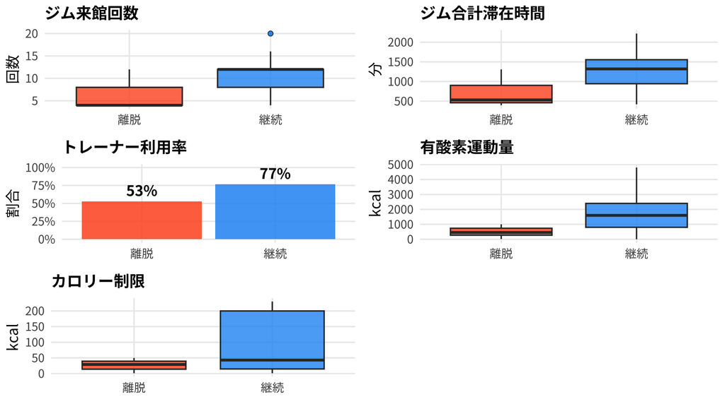

```r
# ── トレーニング行動と継続の関係 ──────────────────────
# 継続者と離脱者のトレーニング行動の違いを
# 箱ひげ図で比較する

# ── 分析用データの準備 ────────────────────────────────
train_cont <- master %>%

  # トレーニングログがあるユーザーのみ抽出
  # gym_visitsがNAのユーザーは除外
  filter(!is.na(gym_visits)) %>%

  # 分析に必要な列のみ選択
  select(continued_lbl, aerobic, calorie_ctrl,
         trainer, gym_visits, gym_hours) %>%

  # トレーナー利用フラグを文字列に変換
  # 0 → "未利用", 1 → "利用"
  mutate(trainer = factor(
    trainer,
    labels = c("未利用", "利用")
  ))

# ── ① ジム来館回数の比較 ─────────────────────────────
# 継続者 vs 離脱者のジム来館回数の分布を比較

p_visits <- ggplot(train_cont, aes(x = continued_lbl, y = gym_visits,
                                    fill = continued_lbl)) +
  geom_boxplot(alpha = 0.8, outlier.shape = 21) +
  scale_fill_manual(values = rev(PALETTE)) +
  labs(title = "ジム来館回数", x = NULL, y = "回数", fill = NULL) +
  theme(legend.position = "none")

# ── ② ジム合計滞在時間の比較 ─────────────────────────
p_hours <- ggplot(train_cont, aes(x = continued_lbl, y = gym_hours,
                                   fill = continued_lbl)) +
  geom_boxplot(alpha = 0.8, outlier.shape = 21) +
  scale_fill_manual(values = rev(PALETTE)) +
  labs(title = "ジム合計滞在時間", x = NULL, y = "分", fill = NULL) +
  theme(legend.position = "none")

# ── ③ トレーナー利用率の比較 ─────────────────────────
p_trainer <- train_cont %>%
  count(continued_lbl, trainer) %>%
  group_by(continued_lbl) %>%
  mutate(pct = n / sum(n)) %>%
  filter(trainer == "利用") %>%
  ggplot(aes(x = continued_lbl, y = pct, fill = continued_lbl)) +
  geom_col(alpha = 0.85) +
  geom_text(aes(label = percent(pct, 1)), vjust = -0.5, fontface = "bold") +
  scale_fill_manual(values = rev(PALETTE)) +
  scale_y_continuous(labels = percent, limits = c(0, 1)) +
  labs(title = "トレーナー利用率", x = NULL, y = "割合", fill = NULL) +
  theme(legend.position = "none")

# ── ④ 有酸素運動量の比較 ─────────────────────────────
p_aerobic <- ggplot(train_cont, aes(x = continued_lbl, y = aerobic,
                                     fill = continued_lbl)) +
  geom_boxplot(alpha = 0.8, outlier.shape = 21) +
  scale_fill_manual(values = rev(PALETTE)) +
  labs(title = "有酸素運動量", x = NULL, y = "kcal", fill = NULL) +
  theme(legend.position = "none")

# ── ⑤ カロリー制限の比較 ─────────────────────────────
p_calorie <- ggplot(train_cont, aes(x = continued_lbl, y = calorie_ctrl,
                                     fill = continued_lbl)) +
  geom_boxplot(alpha = 0.8, outlier.shape = 21) +
  scale_fill_manual(values = rev(PALETTE)) +
  labs(title = "カロリー制限", x = NULL, y = "kcal", fill = NULL) +
  theme(legend.position = "none")

gridExtra::grid.arrange(p_visits, p_hours, p_trainer, p_aerobic, p_calorie, ncol = 2) # 2列配置
```

> **【トレーニング行動と継続の関係】解釈**

> **トレーナー利用率:** 継続者の77%がトレーナーを利用しているのに対し、 離脱者は53%にとどまる。 トレーナーとの関係構築が 継続に寄与している可能性がある。

> **カロリー制限:** 継続者の方がカロリー管理を 積極的に行っている傾向がある。 食事管理とジム継続の 相乗効果が示唆される。

> **総括:** 継続者と離脱者の最大の違いは 「運動量・滞在時間の多さ」であり、 単なる来館回数だけでなく 積極的なトレーニングへの 取り組み姿勢が継続を左右している。

## 体の変化と継続の関係

**コードを表示**

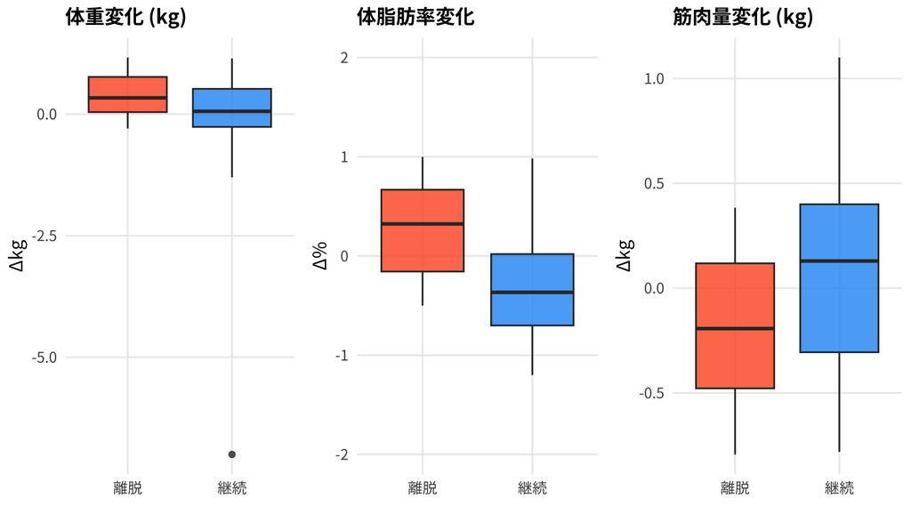

```r
# ── 体組成変化と継続の関係 ────────────────────────────
# 入会から30日間の体組成変化（体重・体脂肪率・筋肉量）が
# 継続・離脱にどう関係するかを箱ひげ図で比較する

# ── 分析用データの準備 ────────────────────────────────
body_cont <- master %>%
  select(continued_lbl, delta_weight, delta_bodyfat, delta_muscle)

# ── ① 体重変化の比較 ─────────────────────────────────
p_w <- ggplot(body_cont, aes(x = continued_lbl, y = delta_weight,
                               fill = continued_lbl)) +
  geom_boxplot(alpha = 0.8) +
  scale_fill_manual(values = rev(PALETTE)) +
  labs(title = "体重変化 (kg)", x = NULL, y = "Δkg", fill = NULL) +
  theme(legend.position = "none")

# ── ② 体脂肪率変化の比較 ─────────────────────────────
# delta_bodyfatは元データが非常に小さい値
# → × 100 して%ポイントに変換して表示
p_f <- ggplot(body_cont, aes(x = continued_lbl, y = delta_bodyfat * 100,
                               fill = continued_lbl)) +
  geom_boxplot(alpha = 0.8) +
  scale_fill_manual(values = rev(PALETTE)) +

  # 外れ値を除外してズームイン
  # scale_y_continuousと違い、外れ値を削除せず
  # 表示範囲だけを変更する（箱の形状は変わらない）
  coord_cartesian(ylim = c(-2, 2)) +
  labs(title = "体脂肪率変化", x = NULL, y = "Δ%", fill = NULL) +
  theme(legend.position = "none")

# ── ③ 筋肉量変化の比較 ───────────────────────────────
# 継続者 vs 離脱者の筋肉量変化を比較
# delta_muscle: プラス=筋肉増加, マイナス=筋肉減少
p_m <- ggplot(body_cont, aes(x = continued_lbl, y = delta_muscle,
                               fill = continued_lbl)) +
  geom_boxplot(alpha = 0.8) +
  scale_fill_manual(values = rev(PALETTE)) +
  labs(title = "筋肉量変化 (kg)", x = NULL, y = "Δkg", fill = NULL) +
  theme(legend.position = "none")

gridExtra::grid.arrange(p_w, p_f, p_m, ncol = 3)
```

> **【体組成変化と継続の関係】解釈**

> **体重変化:** 継続者・離脱者ともに体重変化は ほぼ0kg付近に集中しており、 大きな差は見られない。 体重変化だけでは継続・離脱を 区別することは難しい。

> **体脂肪率変化:** 離脱者の体脂肪率は増加傾向であるのに対し、 継続者は減少傾向である。 体脂肪が減少しているユーザーは トレーニングの成果を実感しやすく 継続につながっている可能性がある。

> **筋肉量変化:** 継続者の筋肉量変化の中央値は約+0.1kgと わずかに増加しているのに対し、 離脱者は約-0.2kgと減少傾向にある。 筋肉量の増加はトレーニング効果の 実感につながり、継続率を高める 可能性がある。

> **総括:** 体重よりも**体脂肪率の減少**と **筋肉量の増加**が継続と関連している。 入会初期に体組成の改善を実感させる プログラムが継続率向上に効果的と考えられる。 → 月1回の体組成測定の義務化と アプリでの変化の可視化を推奨する。

## ① 施策提案

**継続者増加に向けた施策提案**

全体の継続率はわずか**30%（60人）**であり、 **70%（140人）**が30日以内に離脱している。 離脱防止が最優先課題である。

**A. トレーナーフォローアップの強化**

トレーナーを利用した継続者は77%、 離脱者は53%とトレーナー利用率に大きな差がある。

→ 初月レクチャー後も**月1回のトレーナー面談**を 標準メニュー化し、継続的なサポートを提供する。

**B. ジム来館頻度・滞在時間の促進**

→ **週3回以上来館者へのポイント還元**・ 目標達成バッジ制度を導入し来館を促進する。

**C. 30〜34歳向けの特別プログラム**

30〜34歳の継続率が26%と全年齢層で最も低く、 仕事・育児で多忙な世代の離脱が目立つ。

→ **短時間（30分）集中プログラム**を整備し、 忙しい世代でも通いやすい環境を作る。

**D. エリア別マーケティングの強化**

四国地方・北海道地方の継続率が50%と高い一方、 関東地方・九州地方は30%と低い。

→ 都市部ユーザー向けに**オンライン併用プラン**を 提供し、通いにくい環境をカバーする。

**E. 男性ユーザーへの重点施策**

女性（32%）より男性（28%）の継続率が低い。

→ 男性向けに**筋力・体型変化を数値で見える化**する 進捗レポート機能を導入する。

**F. 有酸素運動プログラムの充実**

→ **ランニングマシン・バイクの使い方講習**を 入会1週目に実施し、有酸素運動習慣を定着させる。

**G. 体組成変化の見える化**

継続者は体脂肪率が減少・筋肉量が増加する傾向がある。

→ **月1回の体組成測定を必須化**し、 アプリで変化をグラフ表示して モチベーション維持につなげる。

# ② 商品購入金額の影響要素分析

## 購入金額の分布

**コードを表示**

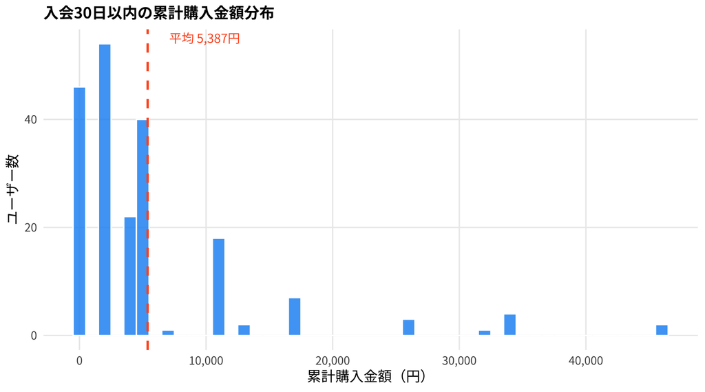

```r
# ── 購入金額の分布 ────────────────────────────────────
# 入会から30日以内の累計購入金額の分布を
# ヒストグラムで可視化する

ggplot(users, aes(x = total_purchase)) +

  # binwidth = 1000 → 1,000円刻みで集計
  geom_histogram(
    binwidth = 1000,
    fill     = PALETTE[1],
    color    = "white",
    alpha    = 0.85
  ) +

  # 平均値の縦線を追加
  # linetype = "dashed" → 破線
  geom_vline(
    xintercept = mean(users$total_purchase),
    linetype   = "dashed",
    color      = PALETTE[2],  # オレンジ色
    linewidth  = 1
  ) +

  # 平均値のテキストラベルを追加
  annotate(
    "text",
    x     = mean(users$total_purchase) + 4500,
    y     = Inf,
    vjust = 1.5,
    label = paste0(
      "平均 ",
      comma(round(mean(users$total_purchase))),
      "円"
    ),
    color = PALETTE[2],
    size  = 4
  ) +

  # x軸を3桁区切り（例: 10,000）で表示
  scale_x_continuous(labels = comma) +

  labs(
    title = "入会30日以内の累計購入金額分布",
    x     = "累計購入金額（円）",
    y     = "ユーザー数"
  )
```

> **【購入金額分布】解釈**

> 購入金額は0円〜40,000円以上まで 広く分布しており、 標準偏差（7,914円）が平均を大きく上回ることから ユーザー間のばらつきが非常に大きい。

> → 未購入ユーザーへの初回購買促進が 売上向上の最優先課題である。

## 属性別の平均購入金額

**コードを表示**

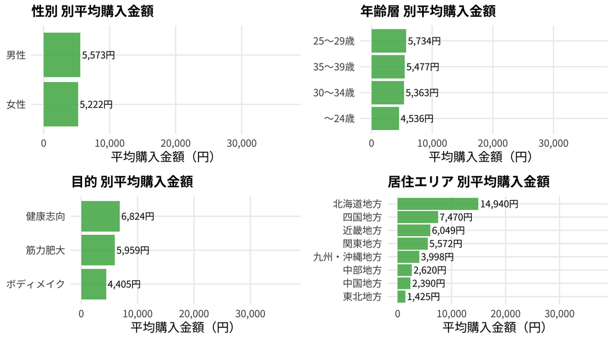

```r
plot_purchase_by <- function(data, var, label) {
  data %>%
    group_by(.data[[var]]) %>%
    summarise(mean_purchase = mean(total_purchase, na.rm = TRUE), .groups = "drop") %>%
    ggplot(aes(x = fct_reorder(.data[[var]], mean_purchase), y = mean_purchase)) +
    geom_col(fill = "#4CAF50", alpha = 0.85) +
    geom_text(aes(label = paste0(comma(round(mean_purchase)), "円")),
              hjust = -0.05, size = 3.5) +
    coord_flip() +
    scale_y_continuous(labels = comma, limits = c(0, max(data$total_purchase) * 0.8)) +
    labs(title = paste(label, "別平均購入金額"), x = NULL, y = "平均購入金額（円）")
}

p1 <- plot_purchase_by(users, "gender_lbl",  "性別")
p2 <- plot_purchase_by(users, "age_group",   "年齢層")
p3 <- plot_purchase_by(users, "purpose_lbl", "目的")
p4 <- plot_purchase_by(users, "area_name",   "居住エリア")

gridExtra::grid.arrange(p1, p2, p3, p4, ncol = 2)
```

**コードを表示**

[figure not shown]

```r
# ── 属性別の平均購入金額 ──────────────────────────────
# 性別・年齢層・目的・居住エリア別に
# 平均購入金額を比較する横棒グラフを作成する


plot_purchase_by <- function(data, var, label) {
  data %>%
    # 指定した変数でグループ化
    group_by(.data[[var]]) %>%

    # グループ別の平均購入金額を計算
    summarise(
      mean_purchase = mean(total_purchase, na.rm = TRUE),
      .groups = "drop"
    ) %>%

    # 平均購入金額の高い順に並べて横棒グラフを作成
    ggplot(aes(
      x = fct_reorder(.data[[var]], mean_purchase),
      y = mean_purchase
    )) +
    geom_col(fill = "#4CAF50", alpha = 0.85) +

    # バーの右端に金額ラベルを表示
    # comma()で3桁区切り（例: 5,573）
    geom_text(
      aes(label = paste0(comma(round(mean_purchase)), "円")),
      hjust = -0.05,  # ラベルをバーの右側に少しずらす
      size  = 3.5
    ) +

    coord_flip() +  # 横棒グラフに変換

    # x軸の範囲を設定
    # max * 0.8 → ラベルが見切れないよう余白を確保
    scale_y_continuous(
      labels = comma,
      limits = c(0, max(data$total_purchase) * 0.8)
    ) +

    labs(
      title = paste(label, "別平均購入金額"),
      x     = NULL,
      y     = "平均購入金額（円）"
    )
}

# ── 4つの属性別グラフを作成 ──────────────────────────
p1 <- plot_purchase_by(users, "gender_lbl",  "性別")
p2 <- plot_purchase_by(users, "age_group",   "年齢層")
p3 <- plot_purchase_by(users, "purpose_lbl", "目的")
p4 <- plot_purchase_by(users, "area_name",   "居住エリア")

# ── 2列×2行のグリッドで表示 ──────────────────────────
gridExtra::grid.arrange(p1, p2, p3, p4, ncol = 2)
```

> **【属性別平均購入金額】解釈**

> **性別:** 男性（5,573円）が女性（5,222円）より わずかに高いが差は小さく、 性別による購入金額への影響は限定的である。

> **年齢層:** 25〜29歳（5,734円）が最も高く、 〜24歳（4,536円）が最も低い。 若年層は購買力が低い傾向があり、 学生向けの割引施策が有効と考えられる。

> **目的:** 健康志向（6,824円）が最も高く、 ボディメイク（4,405円）が最も低い。 健康志向ユーザーはサプリ・グッズへの 投資意識が高いと考えられる。 ボディメイクユーザーへの購買促進施策が 売上向上の余地として存在する。

> **居住エリア:** 北海道地方（14,940円）が突出して高く、 他エリアの平均（約4,500円）の 約3倍の購入金額を記録している。 一方、東北地方（1,425円）・中国地方（2,390円） が低く、エリア間の差が非常に大きい。

> **総括:** エリアによる購入金額の差が最も大きく、 北海道地方への重点施策が 売上向上に最も効果的である。 また健康志向ユーザーの高購買傾向を活かした クロスセル施策も有効である。

## 商品カテゴリ別売上構成

**コードを表示**

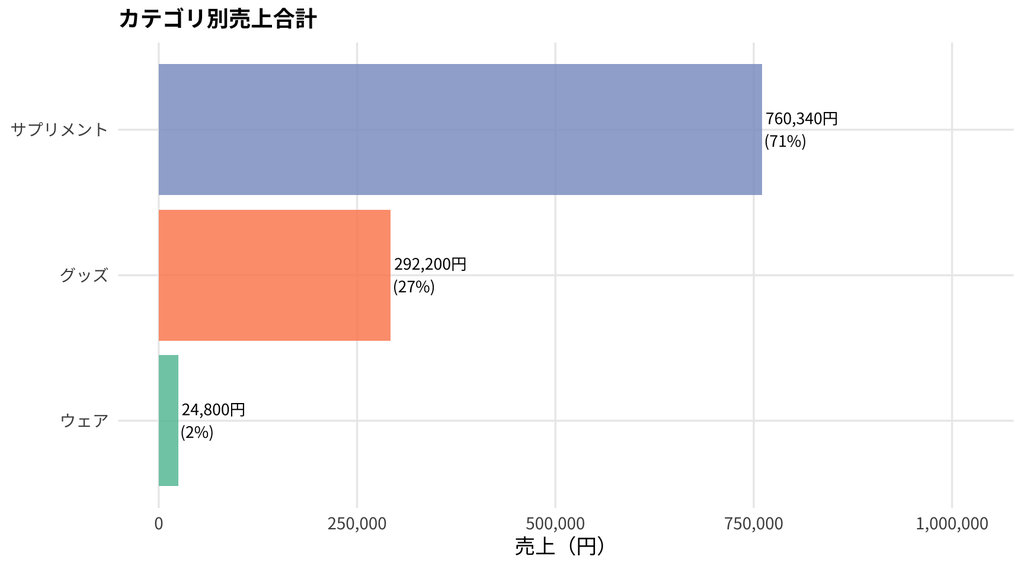

```r
# ── 商品カテゴリ別売上構成 ────────────────────────────

# ── Step 1: 購入ログに商品情報を結合 ─────────────────
purchase_detail <- purchase %>%
  # 商品マスタから必要な列のみ選択して結合
  # product_id をキーに商品名・カテゴリを追加
  left_join(
    products %>% select(product_id, product_name, category),
    by = "product_id"
  )

# ── Step 2: カテゴリ別に売上を集計 ───────────────────
cat_summary <- purchase_detail %>%
  group_by(category) %>%
  summarise(
    total_amount = sum(amount),  # カテゴリ別売上合計
    order_count  = n(),          # カテゴリ別注文件数
    .groups      = "drop"
  ) %>%

  # 各カテゴリの売上構成比を計算
  # pct = カテゴリ売上 / 全体売上
  mutate(pct = total_amount / sum(total_amount))

# ── Step 3: 横棒グラフで可視化 ───────────────────────
ggplot(
  cat_summary,
  aes(
    x    = fct_reorder(category, total_amount), # 売上順に並べる
    y    = total_amount,
    fill = category  # カテゴリ別に色分け
  )
) +
  geom_col(alpha = 0.85) +

  # バーの右端に売上金額と構成比を表示
  geom_text(
    aes(label = paste0(
      comma(total_amount), "円\n",  # 売上金額（改行）
      "(", percent(pct, 1), ")"     # 構成比
    )),
    hjust = -0.05,  # バーの右側に少しずらす
    size  = 3.5
  ) +

  coord_flip() +  # 横棒グラフに変換

  scale_y_continuous(
    labels = comma,
    limits = c(0, max(cat_summary$total_amount) * 1.35)
  ) +

  # カテゴリ別に色を自動設定
  scale_fill_brewer(palette = "Set2") +

  labs(
    title = "カテゴリ別売上合計",
    x     = NULL,
    y     = "売上（円）",
    fill  = "カテゴリ"
  ) +
  theme(legend.position = "none")
```

> **【商品カテゴリ別売上構成】解釈**

> **売上構成:**

> | カテゴリ | 売上合計 | 構成比 |
> | --- | --- | --- |
> | サプリメント | 760,340円 | 71% |
> | グッズ | 292,200円 | 27% |
> | ウェア | 24,800円 | 2% |
> | **合計** | **1,077,340円** | **100%** |

> **サプリメント**が売上の**71%**を占める 圧倒的な主力カテゴリである。 プロテイン・EAA・マルチビタミンなどの 消耗品が繰り返し購入されるため、 高い売上を維持していると考えられる。

> **グッズ**は27%と2位だが、 トレーニングマット・腹筋ローラーなど 一度購入すると再購入が少ない商品が中心である。

> **ウェア**はわずか2%（24,800円）と 極めて低い。 ウェアはジム外でも購入できるため、 ジムでの購買動機が薄いと考えられる。

> **【施策への示唆】** サプリメントの売上強化が最優先である。 特に消耗品のリピート購入を促進するため、 定期購入割引・まとめ買い割引の 導入が効果的である。 ウェアは売上が低いため、 ジム限定カラー・メンバー割引など ジムならではの付加価値をつけることで 購買動機を高める工夫が必要である。

**コードを表示**

```r
# ── 商品別売上ランキング ──────────────────────────────
# 商品名・カテゴリ別に注文数と売上合計を集計しテーブル形式で表示する

purchase_detail %>%
  # 商品名とカテゴリでグループ化
  group_by(product_name, category) %>%

  summarise(
    注文数   = n(),          # 商品別の注文件数
    売上合計 = sum(amount),  # 商品別の売上合計（円）
    .groups  = "drop"
  ) %>%

  # 注文数の多い順に並べ替え
  arrange(desc(注文数)) %>%

  # 列名を日本語に変更（レポート用）
  rename(
    商品名   = product_name,
    カテゴリ = category
  ) %>%

  # HTMLテーブルとして表示
  kable(
    format      = "html",              # HTML形式で出力
    caption     = "商品別売上ランキング",
    format.args = list(big.mark = ","), # 数値を3桁区切りに
    align       = c("l","l","r","r")   # 左左右右で整列
  ) %>%

  kable_styling(
    bootstrap_options = c("striped",  # 行を交互に色付け
                          "hover",    # マウスオーバーでハイライト
                          "bordered"),# 罫線を追加
    full_width = FALSE,  # テーブル幅を内容に合わせる
    position   = "left"  # テーブルを左寄せ
  )
```

商品別売上ランキング

| 商品名 | カテゴリ | 注文数 | 売上合計 |
| --- | --- | --- | --- |
| プロテイン(1kg) | サプリメント | 99 | 376,200 |
| プロテインシェイカー | サプリメント | 78 | 76,440 |
| 腹筋ローラー | グッズ | 48 | 91,200 |
| マルチビタミン | サプリメント | 38 | 95,000 |
| EAA | サプリメント | 37 | 155,400 |
| トレーニングマット | グッズ | 17 | 64,600 |
| グルタミン | サプリメント | 16 | 30,400 |
| トレーニングベルト | グッズ | 10 | 89,000 |
| クレアチン | サプリメント | 9 | 17,100 |
| コンディションガン | グッズ | 6 | 47,400 |
| Tシャツ | ウェア | 2 | 5,600 |
| パンツ | ウェア | 2 | 7,600 |
| ランニングシューズ | ウェア | 2 | 11,600 |
| プロテイン(3kg) | サプリメント | 1 | 9,800 |

> **【商品別売上ランキング】解釈**

> **注文数ランキング:**

> | 順位 | 商品名 | 注文数 | 売上合計 |
> | --- | --- | --- | --- |
> | 1位 | プロテイン(1kg) | 99件 | 376,200円 |
> | 2位 | プロテインシェイカー | 78件 | 76,440円 |
> | 3位 | 腹筋ローラー | 48件 | 91,200円 |
> | 4位 | マルチビタミン | 38件 | 95,000円 |
> | 5位 | EAA | 37件 | 155,400円 |

> **注目点①: プロテイン(1kg)が最多注文** 注文数99件と圧倒的な1位だが、 売上合計は376,200円（単価3,800円）である。 プロテイン(3kg)（単価9,800円）への アップセルで客単価向上が期待できる。

> **注目点②: EAAの高い売上効率** 注文数37件と5位だが 売上合計155,400円（単価4,200円）は 注文数2位のシェイカー（76,440円）の 約2倍である。 EAAはプロテイン購入者への クロスセル商品として効果的である。

> **注目点③: プロテインシェイカーの低単価** 注文数78件と2位だが 単価980円のため売上は76,440円と低い。 シェイカーはプロテイン購入時の セット販売で自然に売れている 可能性が高い。

> **注目点④: グッズの高額商品** トレーニングベルト（89,000円）は 注文数10件だが単価8,900円と高く、 少数でも高売上を生む商品である。 コンディションガン（単価7,900円）も 同様の高単価商品として注目すべきである。

> **【施策への示唆】** プロテイン(1kg)購入者に対して: → プロテイン(3kg)へのアップセル → EAA・マルチビタミンのクロスセル → シェイカーのセット販売 を組み合わせることで 客単価の大幅な向上が期待できる。

## ② 施策提案

**② 商品販売売上向上に向けた施策提案**

**A. サプリメントのクロスセル強化**

売上の71%をサプリメントが占める主力カテゴリ。 プロテイン購入者にシェイカー・ビタミンをセット提案。

→ 入会時「**スターターセット** （プロテイン＋シェイカー＋クレアチン）」 割引バンドルを導入し、初回購買単価を向上させる。

**B. トレーナー利用者への商品提案**

→ トレーナーが推奨商品を記載する **「アドバイスカード」制度**を設置し、 購買のきっかけを作る。

**C. 来館頻度連動のレコメンド通知**

→ **週3回以上来館者**にアプリから サプリ・グッズのプッシュ通知を配信し、 購買タイミングを逃さない。

**D. 購入ゼロユーザーへの初回購買促進**

→ 入会時に**500円クーポン**を配布し、 初回購買のハードルを下げる。 一度購入したユーザーは リピート購入につながりやすい。

**E. 若年層（〜24歳）への購買促進**

〜24歳の平均購入金額が4,536円と 全年齢層で最も低い。

→ **学生割引・SNSシェアキャンペーン**で 若年層の購買意欲を刺激する。 口コミ効果による新規顧客獲得も期待できる。

**F. トレーナー未利用者への購買促進**

→ トレーナー未利用者へ **サプリ無料サンプル**を配布し、 購買のきっかけを作る。

**G. プロテイン(3kg)の販売強化**

プロテイン(1kg)は注文数99件と最も売れているが、 3kgは注文数1件のみ。 3kgの単価（9,800円）は1kgの約2.6倍である。

→ 1kg購入者へ3kgの**割引オファー**を送り、 大容量版へのアップセルを促進する。 → 「1kgを3回買うより3kgが得！」という メッセージングが効果的である。

**H. EAAのクロスセル強化**

EAAは注文数37件だが売上155,400円と 注文数2位のシェイカー（76,440円）の 約2倍の売上を誇る高単価商品。

→ プロテイン購入者へEAAを **セット割引**で提案し、 客単価をさらに向上させる。

# ③ 継続率予測モデル

### データ準備

**コードを表示**

```r
# ══════════════════════════════════════════════════
# ③ 継続率予測モデル
# 目的: 入会から30日以内のデータから
#       30日後の継続・離脱を予測する
#       2値分類モデルを構築する
# アルゴリズム: Random Forest
# 評価方法:    5-Fold Cross Validation
# 評価指標:    AUC（ROC曲線の面積）
# ══════════════════════════════════════════════════

# ── モデル用データの準備 ──────────────────
# masterテーブルから予測に使う列のみ選択する
# 選択基準: 入会30日以内に取得できるデータのみ使用

model_data <- master %>%

  mutate(
    # 欠損値（NA）を0で補完
    # 理由: Random Forestはデフォルトでは
    #       NAを扱えないため事前に補完が必要
    # 解釈: トレーニングログがないユーザーは
    #       「来館0回・運動0kcal」として扱う
    gym_visits = replace_na(gym_visits, 0),
    gym_hours  = replace_na(gym_hours,  0),
    trainer    = replace_na(trainer,    0),
    aerobic    = replace_na(aerobic,    0)
  ) %>%

  # 予測に使う特徴量（説明変数）と
  # 予測対象（目的変数）を選択
  select(
    continued,      # 目的変数: 継続=1, 離脱=0
    gym_visits,     # 特徴量: ジム来館回数
    gym_hours,      # 特徴量: ジム合計滞在時間
    trainer,        # 特徴量: トレーナー利用フラグ
    aerobic,        # 特徴量: 有酸素運動量
    age,            # 特徴量: 年齢
    total_purchase  # 特徴量: 累計購入金額
  ) %>%

  mutate(
    # continuedを数値→因子型に変換
    # 理由: Random Forestに「これは分類問題」と伝えるため
    # levels: 0=離脱, 1=継続 の順序を明示
    # labels: グラフ・出力で表示する文字列
    continued = factor(
      continued,
      levels = c(0, 1),
      labels = c("離脱", "継続")
    )
  )

# データの確認
cat("行数:", nrow(model_data), "\n")
```

```
行数: 200
```

**コードを表示**

```r
cat("継続:", sum(model_data$continued == "継続"), "\n")
```

```
継続: 60
```

**コードを表示**

```r
cat("離脱:", sum(model_data$continued == "離脱"), "\n")
```

```
離脱: 140
```

> **【データ準備の確認】**

> | 項目 | 値 |
> | --- | --- |
> | 総サンプル数 | 200人 |
> | 継続 | 60人（30%） |
> | 離脱 | 140人（70%） |
> | 特徴量数 | 6変数 |

> **クラス不均衡について:** 継続（30%）と離脱（70%）で サンプル数に偏りがある。 このような場合、精度（Accuracy）より **AUC**で評価する方が適切である。 AUCはクラス不均衡の影響を 受けにくい評価指標である。

### Random Forest 分類モデル（5-Fold CV）

**コードを表示**

```r
# ── Random Forest 分類モデルの構築 ────────
set.seed(42)
# Random Forestはランダムな要素を含むため
# 同じ結果を再現するためにシードを固定する

ctrl <- trainControl(
  method          = "cv", # Cross Validation（交差検証）
  number          = 5, # 5-Fold CV: データを5分割する
  classProbs      = TRUE,
  # 予測結果を確率で出力する（例: 継続確率=82%）
  # AUCの計算にはこの確率が必要なためTRUEにする

  summaryFunction = twoClassSummary, # 2クラス分類（継続/離脱）用の評価関数

  savePredictions = "final"
  # 各Foldの予測結果を保存する
  # → 後でROC曲線を描くために必要
)

rf_churn <- train(
  continued ~ ., # "~"using "." All other columns
  data      = model_data,
  method    = "rf", # Random Forest
  metric    = "ROC",
  trControl = ctrl,   # 上で設定した交差検証のルールを適用
  ntree     = 300, # 作成するRandom Treeの数

  tuneGrid  = data.frame(mtry = c(1, 2, 3, 4, 5, 6))
  # mtry: 各分岐点でランダムに選ぶ特徴量の数
  # 特徴量数=6なので1〜6を全て試す
  # Rが自動的に最良のmtryを選択する
)

cat("Best mtry:", rf_churn$bestTune$mtry, "\n")
```

```
Best mtry: 2
```

### モデルの評価（AUC）

**コードを表示**

```r
# ── モデルの評価（AUC） ───────────────────
# 5-Fold CVの予測結果からAUCを計算する

# ── 最良のmtryの予測結果を取得 ───────────────────
preds <- rf_churn$pred %>%
  filter(mtry == rf_churn$bestTune$mtry)

# ── ROCオブジェクトの作成 ─────────────────────────
roc_obj <- roc(
  response  = preds$obs,
  # response: 実際の正解ラベル

  predictor = preds$継続,
  # predictor: 「継続」である予測確率

  levels    = c("離脱", "継続")
  # levels: どちらを陰性（0）・陽性（1）とするか
)


# ── AUCの計算 ────────────────────────────────────
auc_val <- round(auc(roc_obj), 3)

# round(..., 3): 小数点3桁に丸める
cat("AUC =", auc_val, "\n")
```

```
AUC = 0.968
```

### ROC曲線

**コードを表示**

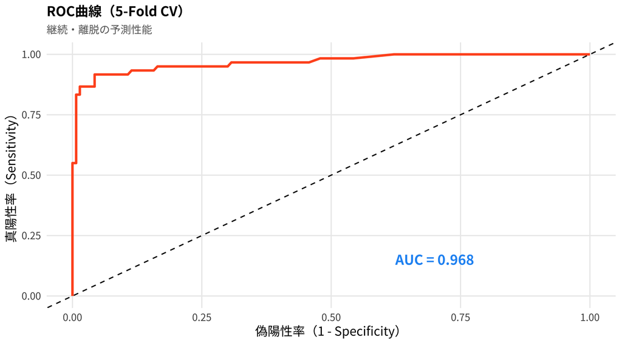

```r
# ── ROC曲線用データの準備 ────────────────────────
roc_df <- data.frame(
  # roc_objから特異度・感度の値を取得
  # rev()で逆順にして左下から右上への曲線にする

  specificity = rev(roc_obj$specificities),
  # specificity: 特異度
  # = 離脱者を正しく「離脱」と予測できた割合
  # x軸は (1 - specificity) = 偽陽性率

  sensitivity = rev(roc_obj$sensitivities)
  # sensitivity: 感度（真陽性率）
  # = 継続者を正しく「継続」と予測できた割合
  # y軸に使用
)

# ── ROC曲線の描画 ─────────────────────────────────
ggplot(roc_df, aes(
  x = 1 - specificity,  # 偽陽性率（x軸）
  y = sensitivity        # 真陽性率（y軸）
)) +

  # ROC曲線本体
  geom_line(
    color     = PALETTE[2],  # オレンジ色
    linewidth = 1.2
  ) +

  # 対角線（ランダム予測の基準線）
  # この線より上にあるほど良いモデル
  geom_abline(linetype = "dashed") +

  # AUC値をグラフ内に表示
  annotate(
    "text",
    x        = 0.7,      # グラフ右下に配置
    y        = 0.15,
    label    = paste0("AUC = ", auc_val),
    size     = 5,
    fontface = "bold",
    color    = PALETTE[1]  # 青色
  ) +

  labs(
    title    = "ROC曲線（5-Fold CV）",
    subtitle = "継続・離脱の予測性能",
    x        = "偽陽性率（1 - Specificity）",
    y        = "真陽性率（Sensitivity）"
  )
```

> **【ROC曲線・AUCの解釈】**

> **AUC = 0.968（5-Fold CV）**

> | AUC値 | 評価 |
> | --- | --- |
> | 0.5 | ランダム予測 |
> | 0.7 | 許容範囲 |
> | 0.8 | 良い |
> | 0.9 | 非常に良い |
> | **0.968** | **ほぼ完璧** |

> **ROC曲線の読み方:** 曲線が左上に近いほど良いモデルである。 本モデルの曲線は開始直後から 真陽性率が0.90近くまで急上昇しており、 非常に少ない偽陽性率で 多くの継続者を正確に識別できている。

> **汎化性能（Generalization性能）:** 5-Fold CVにより、モデルは 学習に使用していない未知データに対しても 高い予測性能を維持することが確認された。 これにより過学習のリスクは低く、 実際の新規入会者への適用が期待できる。

> **ビジネスへの活用:** 入会2週間時点でこのモデルを適用することで、 離脱リスクの高いユーザーを早期に特定し、 トレーナー介入・特別プログラムの 優先的な提供が可能となる。

## 変数重要度

**コードを表示**

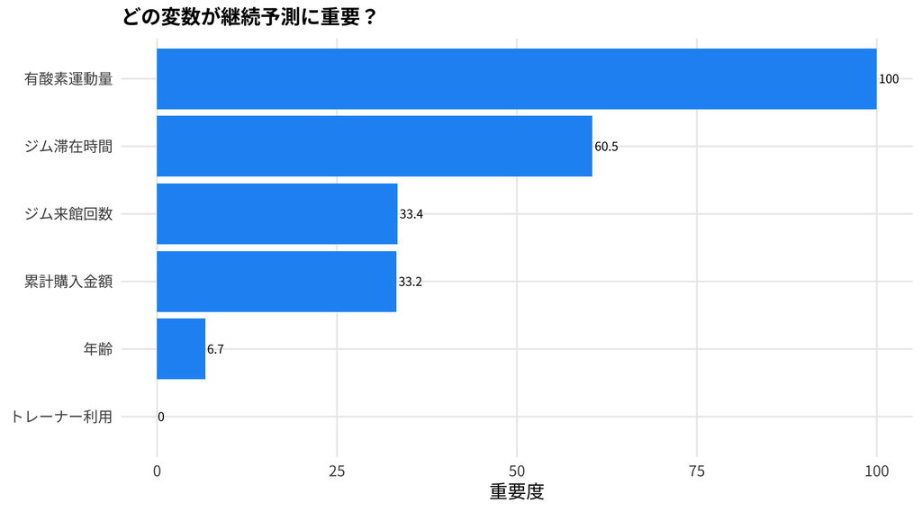

```r
# ── 変数重要度の可視化 ────────────────────
# どの特徴量が継続予測に最も貢献しているかを確認する
varImp(rf_churn)$importance %>%
  # varImp(): 各変数の重要度スコアを取得
  # $importance: 重要度の数値テーブルを取り出す
  # スコアは0〜100で正規化されている
  # 最重要変数 = 100, 無関係な変数 = 0

  # 行名（変数名）をoverallという列に変換
  # rownames_to_column が必要な理由:
  # varImp()の出力は変数名が行名として格納されているため
  # ggplotで使うには列に変換する必要がある

  rownames_to_column("feature") %>%
  arrange(desc(Overall)) %>%
  mutate(feature = recode(feature,
    "gym_visits"     = "ジム来館回数",
    "gym_hours"      = "ジム滞在時間",
    "trainer"        = "トレーナー利用",
    "aerobic"        = "有酸素運動量",
    "age"            = "年齢",
    "total_purchase" = "累計購入金額"
  )) %>%
  ggplot(aes(x = fct_reorder(feature, Overall),
             y = Overall)) +
  geom_col(fill = "#2196F3") +
  geom_text(aes(label = round(Overall, 1)),
            hjust = -0.1, size = 3) +
  coord_flip() +
  labs(title = "どの変数が継続予測に重要？",
       x = NULL, y = "重要度")
```

> **【変数重要度の解釈】**

> | 順位 | 変数 | 重要度 | 解釈 |
> | --- | --- | --- | --- |
> | 1位 | 有酸素運動量 | 100 | 最重要変数 |
> | 2位 | ジム滞在時間 | 60.5 | 2番目に重要 |
> | 3位 | ジム来館回数 | 33.4 | 3番目に重要 |
> | 4位 | 累計購入金額 | 33.2 | 購買意欲の指標 |
> | 5位 | 年齢 | 6.7 | ほぼ無関係 |
> | 6位 | トレーナー利用 | 0 | 予測に貢献せず |

> **①有酸素運動量（重要度=100）が最重要:** 継続予測において最も重要な変数であり、 継続者と離脱者を最も明確に区別できる。 有酸素運動量が多いユーザーは トレーニングへの積極的な取り組みを示しており、 継続につながっていると考えられる。

> **②ジム滞在時間・来館回数（60.5/33.4）:** 滞在時間と来館回数も重要だが、 有酸素運動量ほどではない。 「来るだけ」より「積極的に運動する」ことが より重要であることを示している。

> **③累計購入金額（33.2）:** 購入金額も継続の予兆として機能している。 商品を購入したユーザーはジムへの 投資意識が高く、継続しやすい傾向がある。

> **④トレーナー利用（重要度=0）の意外な結果:** ①の分析ではトレーナー利用率が 継続者（77%）と離脱者（53%）で大きく異なった。 しかし予測モデルでは重要度=0となった。

> これは「相関は因果を意味しない」 という統計学の重要な原則を示している。 トレーナー利用は有酸素運動量などの 他の変数で説明できてしまうため、 モデルにとって追加情報にならない。 トレーナー利用は継続の「原因」ではなく 運動熱心さという隠れた変数の 「結果」である可能性が高い。

> **【施策への示唆】** 継続率向上のために最も効果的な施策は トレーナー施策より**有酸素運動量を増やす**ことである。 → ランニングマシン・バイクの 積極的な活用を促すプログラムの整備 → 有酸素運動の目標設定・達成通知機能の導入 → 入会1週目の有酸素運動体験セッションの実施

## ③施策提案

**③ 継続率予測モデルの解釈**

## 継続率予測モデル

**【モデル性能】**

| 指標 | 値 | 評価 |
| --- | --- | --- |
| AUC | 0.968 | ほぼ完璧 |
| 検証方法 | 5-Fold CV | 汎化性能確認済み |

**【変数重要度の解釈】**

| 順位 | 変数 | 重要度 |
| --- | --- | --- |
| 1位 | 有酸素運動量 | 100 |
| 2位 | ジム滞在時間 | 60.5 |
| 3位 | ジム来館回数 | 33.4 |
| 4位 | 累計購入金額 | 33.2 |
| 5位 | 年齢 | 6.7 |
| 6位 | トレーナー利用 | 0 |

継続予測において最も重要な変数は **有酸素運動量（重要度=100）**であり、 次いで**ジム滞在時間（60.5）**、 **ジム来館回数（33.4）**と続く。

これらの結果から、継続するユーザーは 単にジムに来るだけでなく、 **積極的に運動している**ことが示唆される。

**累計購入金額（33.2）**も重要度が高く、 商品を購入したユーザーは ジムへの投資意識が高く継続しやすい 傾向があると解釈できる。

**【注目点: トレーナー利用（重要度=0）】**

①の分析では「トレーナー利用率」が 継続者（77%）vs 離脱者（53%）で 大きく異なっていた。

しかし予測モデルでは**重要度=0**。

これは「**相関は因果を意味しない**」という 統計学の重要な原則を示している。 トレーナー利用は継続と相関するが、 有酸素運動量・滞在時間などの 他の変数で説明できてしまう。

→ トレーナー利用は継続の「**結果**」であり 「**原因**」ではない可能性がある。

**【ビジネスへの示唆】**

継続率向上に最も効くのは **「どれだけ運動したか」**であり 「何回来たか」ではない。

→ 来館回数より運動の質・量を高める施策が効果的！

具体的な施策:

- 有酸素運動プログラムの充実
- ランニングマシン・バイクの活用促進
- 入会1週目の有酸素運動体験セッションの実施
- 運動量の目標設定・達成通知機能の導入

# ④ 購入金額予測モデル

### データ準備

**コードを表示**

```r
# ══════════════════════════════════════════════════
# ④ 購入金額予測モデル
# 目的: 入会から30日以内のデータから
#       30日間の累計購入金額を予測する
#       回帰モデルを構築する
# アルゴリズム: Random Forest（回帰）
# 評価方法:    5-Fold Cross Validation
# 評価指標:    RMSE・MAE・R²
# ══════════════════════════════════════════════════

# ── モデル用データの準備 ──────────────────
model_purchase <- master %>%
  mutate(
    across(c(aerobic, calorie_ctrl, trainer, gym_visits, gym_hours),
           ~ replace_na(., 0)),
    across(c(delta_weight, delta_bodyfat, delta_muscle),
           ~ replace_na(., 0))
  ) %>%

  # 予測に使う特徴量と目的変数を選択
  select(total_purchase, age, gender, purpose, aerobic, calorie_ctrl,
         trainer, gym_visits, gym_hours, delta_weight, delta_bodyfat,
         delta_muscle, continued, area_id, purchased)

cat("サンプル数:", nrow(model_purchase), "\n")
```

```
サンプル数: 200
```

**コードを表示**

```r
cat("購入金額 平均:", comma(round(mean(model_purchase$total_purchase))), "円\n")
```

```
購入金額 平均: 5,387 円
```

**コードを表示**

```r
cat("購入金額 標準偏差:", comma(round(sd(model_purchase$total_purchase))), "円\n")
```

```
購入金額 標準偏差: 7,914 円
```

> **【データ概要】**

> | 項目 | 値 |
> | --- | --- |
> | サンプル数 | 200人 |
> | 購入金額 平均 | 5,387円 |
> | 購入金額 標準偏差 | 7,914円 |

> 標準偏差（7,914円）が平均（5,387円）を 大きく上回っており、 ユーザー間の購入金額に 非常に大きなばらつきがある。 0円の未購入者が多い一方、 一部に高額購入者（40,000円以上）が存在するため。

### Random Forest 回帰モデル（5-Fold CV)

**コードを表示**

```r
# ── Random Forest 回帰モデルの構築 ────────
# 5-Fold Cross Validationで購入金額を予測する
set.seed(42)

# ── 交差検証の設定 ────────────────────────────────
ctrl_reg <- trainControl(
  method = "cv",
  # cv = Cross Validation（交差検証）
  # データを5分割してモデルの汎化性能を測定する
  number          = 5,
  savePredictions = "final"
)

# ── モデルの学習 ──────────────────────────────────
rf_purchase <- train(
  total_purchase ~ ., # "~"using "." All other columns
  data      = model_purchase,
  method    = "rf", # Random Forest
  metric    = "RMSE",
  trControl = ctrl_reg,   # 上で設定した交差検証のルールを適用
  ntree     = 300, # 作成するRandom Treeの数
  tuneGrid  = data.frame(mtry = c(1, 2, 3, 4, 5, 6, 7, 8, 9, 10, 11, 12, 13))
  # mtry: 各分岐点でランダムに選ぶ特徴量の数
  # 特徴量数=14 なので1〜13を全て試す
  # Rが自動的に最良のmtryを選択する
)

cat("Best mtry:", rf_purchase$bestTune$mtry, "\n")
```

```
Best mtry: 5
```

## モデル評価

**コードを表示**

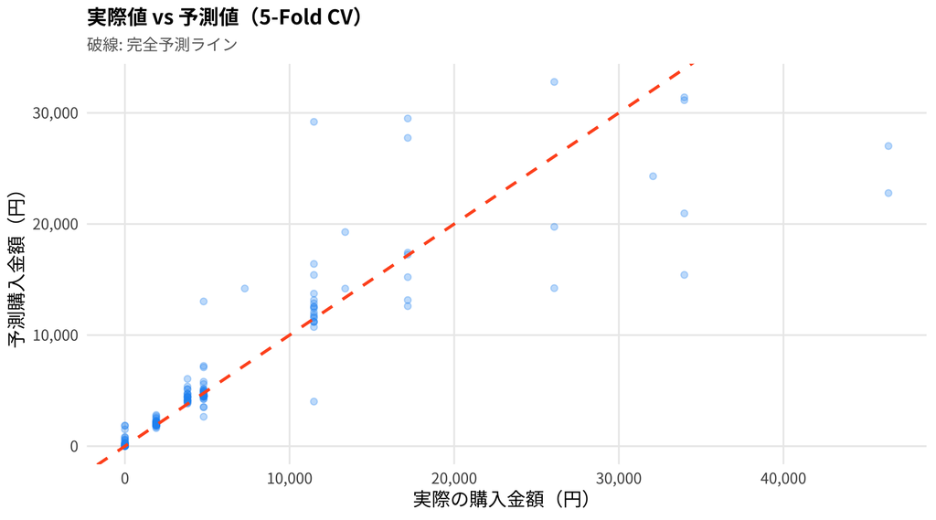

```r
# ── モデルの評価（実際値 vs 予測値） ─────
# 5-Fold CVの予測結果を散布図で可視化する

# ── 最良のmtryの予測結果を取得 ───────────────────
preds_reg <- rf_purchase$pred %>%
  filter(mtry == rf_purchase$bestTune$mtry)
  # → 最良のmtry（=5）の結果のみを抽出する

  # preds_reg の構造:
  # obs  = 実際の購入金額（円）
  # pred = 予測した購入金額（円）

# ── 散布図の作成 ──────────────────────────────────
ggplot(preds_reg, aes(
  x = obs,   # x軸: 実際の購入金額
  y = pred   # y軸: 予測した購入金額
)) +

  # 各ユーザーを点でプロット
  geom_point(
    alpha = 0.3,
    color = PALETTE[1],
    size  = 1.8
  ) +

  # 完全予測ライン（破線）を追加
  geom_abline(
    linetype  = "dashed",
    color     = PALETTE[2],
    linewidth = 1
  ) +

  # 軸を3桁区切りで表示（例: 10,000）
  scale_x_continuous(labels = comma) +
  scale_y_continuous(labels = comma) +

  labs(
    title    = "実際値 vs 予測値（5-Fold CV）",
    subtitle = "破線: 完全予測ライン",
    x        = "実際の購入金額（円）",
    y        = "予測購入金額（円）"
  )
```

> **【実際値 vs 予測値の分析】**

> | 購入金額帯 | 予測精度 | 理由 |
> | --- | --- | --- |
> | ¥0〜5,000 | 高い | サンプルが多い |
> | ¥5,000〜15,000 | 中程度 | ばらつきあり |
> | ¥20,000以上 | 低い | サンプルが少ない |

> **低購入金額帯（¥0〜5,000）:** 点が破線付近に密集しており、 高い精度で予測できている。 未購入者（0円）と少額購入者の パターンをよく学習できている。

> **高購入金額帯（¥20,000以上）:** 点が破線から大きく離れており、 予測誤差が大きくなる傾向がある。 高額購入者のサンプルが少ないため パターン学習が困難であることが原因。 これは回帰モデルで一般的に見られる現象である。

> **全体的な傾向:** 点群は全体的に破線に沿って 右上がりの傾向を示しており、 モデルが購入金額の大まかな 傾向を捉えられていることがわかる。

**コードを表示**

```r
# ── CV結果の数値確認 ──────────────────────
# 5-Fold CVの評価指標（RMSE・MAE・R²）を
# テーブル形式で表示する

# ── 最良のmtryの結果を抽出 ───────────────────────
res <- rf_purchase$results %>%
  # → 最良のmtry（=5）の行のみを抽出
  filter(mtry == rf_purchase$bestTune$mtry) %>%

  # 小数点3桁に丸める（表示用）
  mutate(across(c(RMSE, MAE, Rsquared), ~ round(., 3)))

# ── 結果をテーブル表示 ────────────────────────────
res %>%
  select(mtry, RMSE, MAE, Rsquared) %>%
  rename(`R²` = Rsquared) %>%
　kable(caption = "CV結果（購入金額予測モデル）") %>%
  kable_styling(
    bootstrap_options = c("striped", "hover"),
    full_width = FALSE
  )
```

CV結果（購入金額予測モデル）

| mtry | RMSE | MAE | R² |
| --- | --- | --- | --- |
| 5 | 3431.172 | 1349.17 | 0.889 |

> **【CV結果（購入金額予測モデル）の解釈】**

> | 指標 | 値 | 意味 |
> | --- | --- | --- |
> | mtry | 5 | 最良の特徴量選択数 |
> | RMSE | 3,431円 | 平均予測誤差 |
> | MAE | 1,349円 | 中央値的な予測誤差 |
> | R² | 0.889 | 変動の説明率 |

> **R² = 0.889（非常に良い）:** モデルは購入金額の変動の**88.9%**を 正確に説明できており、 非常に高い予測性能を示している。

> **RMSE = 3,431円 vs MAE = 1,349円:** RMSEとMAEの差が大きい（約2,082円）。 これはRMSEが大きな誤差を より強く罰するためであり、 高額購入者の予測が外れた際に RMSEが大きく跳ね上がることを示す。 実態に近い平均誤差は MAEの**1,349円**と解釈するのが適切である。

> **汎化性能について:** 5-Fold CVにより、モデルは 学習に使用していない未知データに対しても 高い予測性能を維持することが確認された。 過学習のリスクは低く、 実際の新規入会者への適用が期待できる。

> **ビジネスへの活用:** 入会直後のデータからこのモデルを適用し、 高購入見込みユーザー（予測値¥10,000以上）へ プロテイン3kg・コンディションガンなどの 高額商品のターゲット広告を配信することで 商品販売ROIの最大化が期待できる。

## ④施策提案

**④ 購入金額予測モデルの解釈**

**【データ概要】**

| 項目 | 値 |
| --- | --- |
| サンプル数 | 200人 |
| 購入金額 平均 | 5,387円 |
| 購入金額 標準偏差 | 7,914円 |

標準偏差が平均を大きく上回っており、 ユーザー間の購入金額に 大きなばらつきがあることがわかる。 （購入ゼロ円〜40,000円以上まで分布）

**【モデル性能】**

[output not shown]

**【実際値 vs 予測値の分析】**

| 購入金額帯 | 予測精度 | 理由 |
| --- | --- | --- |
| ¥0〜5,000 | 高い | サンプルが多い |
| ¥5,000〜15,000 | 中程度 | ばらつきあり |
| ¥20,000以上 | 低い | サンプルが少ない |

**低購入金額帯（¥0〜5,000）:** → 点が対角線に密集 → 高精度で予測できている

**高購入金額帯（¥20,000以上）:** → 点が対角線から離れる → 予測誤差が大きくなる傾向 → サンプル数が少ないため パターン学習が困難

**【RMSEとMAEの差について】**

[output not shown]

**【ビジネスへの示唆】**

このモデルを活用することで: 入会直後のデータから 30日以内の購入金額を予測し、

**高購入見込みユーザー（予測値¥10,000以上）** → プロテイン3kg・コンディションガンなど 高額商品のターゲット広告を配信

**低購入見込みユーザー（予測値¥0〜3,000）** → 500円クーポン配布で 初回購買のハードルを下げる

# まとめ・総合施策提案

## 分析結果サマリー

[output not shown]

## 優先施策ロードマップ

**今すぐ実施すべき施策(例）**

**継続率向上:**

- 有酸素運動プログラムの充実
- 週3回以上来館者へのポイント還元制度
- 入会1週目の有酸素運動体験セッション

**売上向上:**

- プロテイン購入者へのEAA・3kgアップセル
- 入会時スターターセット割引バンドル導入
- 購入ゼロユーザーへの500円クーポン配布

**モデルの実践的活用方法**

**継続予測モデル（AUC = 0.968）の活用:**

→ 入会2週間時点で離脱リスクスコアを算出 → リスクの高いユーザーへ優先的に トレーナー介入・特別プログラムを提供

→ 入会直後のデータから購入金額を予測 → 高購入見込みユーザーへ 高額商品のターゲット広告を配信 → 低購入見込みユーザーへ クーポンで初回購買を促進